# Statistical Learning Project

Onur Alp Güvercin, 2072249, Su Doğan, 2071957, Işıkay Karakuş, 2071938

July 17, 2023

# House Price Prediction: Regression Techniques

# 1.Aim of The Project

House pricing is of utmost importance in our world, as it impacts individuals, families, and the economy at large. The purchase of a house represents a significant financial decision, often constituting a substantial portion of one’s wealth. The fluctuation of house prices directly influences personal financial stability and the ability to build assets. Moreover, the real estate market, driven by house prices, contributes significantly to economic activity, including property sales, construction, and associated industries.

The aim of our project is to develop a predictive model for house pricing. This project holds great importance considering the large number of people buying houses every year. Housing affordability is a critical issue, and accurate prediction models can help address it. By analyzing market trends and evaluating property values, our model aims to provide individuals, sellers, and industry professionals with valuable insights for making informed decisions. The project contributes to understanding housing market dynamics, assisting with financial planning, and promoting fair and transparent practices in the real estate sector.

Through our research project, our primary objective is to illuminate the key factors that influence house prices, discern the most impactful among them, and formulate an effective estimation framework for predicting the price of a house based on its specific characteristics.

# 2- PREPERATION

# 2.1.Import Libraries

We will import the necessary packages for our analysis;

```r
# Import the libraries
library(rworldmap)
library(knitr)
library(ggplot2)
library(readr)
library(MASS)
library(dplyr)
library(lars)
library(moments)
library(caret)
library(corrplot)
library(gbm)
library(glmnet)
library(effectsize)
```

For this project, we have selected the “House Prices - Advanced Regression Techniques” dataset, which consists of 3 csv files (train, test, and sample submission) and can be found on the Kaggle platform at the following link: https://www.kaggle.com/competitions/house-prices-advanced-regression-techniques

```r
#start
train <- read.csv("train.csv")
test <- read.csv("test.csv")
sample <- read.csv("sample_submission.csv")
summary(train)
```

# 2.2 Data Component

- MSSubClass: Identifies the type of dwelling involved in the sale.
- MSZoning: Identifies the general zoning classification of the sale.
- LotFrontage: Linear feet of street connected to property
- LotArea: Lot size in square feet
- Street: Type of road access to property
- Alley: Type of alley access to property
- LotShape: General shape of property
- LandContour: Flatness of the property
- Utilities: Type of utilities available
- LotConfig: Lot configuration
- LandSlope: Slope of property
- Neighborhood: Physical locations within Ames city limits
- Condition1: Proximity to various conditions
- Condition2: Proximity to various conditions (if more than one is present)
- BldgType: Type of dwelling
- HouseStyle: Style of dwelling
- OverallQual: Rates the overall material and finish of the house
- OverallCond: Rates the overall condition of the house
- YearBuilt: Original construction date
- YearRemodAdd: Remodel date (same as construction date if no remodeling or additions)
- RoofStyle: Type of roof
- RoofMatl: Roof material
- Exterior1st: Exterior covering on house
- Exterior2nd: Exterior covering on house (if more than one material)
- MasVnrType: Masonry veneer type
- MasVnrArea: Masonry veneer area in square feet
- ExterQual: Evaluates the quality of the material on the exterior
- ExterCond: Evaluates the present condition of the material on the exterior
- Foundation: Type of foundation
- BsmtQual: Evaluates the height of the basement
- BsmtCond: Evaluates the general condition of the basement
- BsmtExposure: Refers to walkout or garden level walls
- BsmtFinType1: Rating of basement finished area
- BsmtFinSF1: Type 1 finished square feet
- BsmtFinType2: Rating of basement finished area (if multiple types)
- BsmtFinSF2: Type 2 finished square feet
- BsmtUnfSF: Unfinished square feet of basement area
- TotalBsmtSF: Total square feet of basement area
- Heating: Type of heating
- HeatingQC: Heating quality and condition
- CentralAir: Central air conditioning
- Electrical: Electrical system
- 1stFlrSF: First Floor square feet
- 2ndFlrSF: Second floor square feet
- LowQualFinSF: Low quality finished square feet (all floors)
- GrLivArea: Above grade (ground) living area square feet
- BsmtFullBath: Basement full bathrooms
- BsmtHalfBath: Basement half bathrooms
- FullBath: Full bathrooms above grade
- HalfBath: Half baths above grade
- Bedroom: Bedrooms above grade (does NOT include basement bedrooms)
- Kitchen: Kitchens above grade
- KitchenQual: Kitchen quality
- TotRmsAbvGrd: Total rooms above grade (does not include bathrooms)
- Functional: Home functionality (Assume typical unless deductions are warranted)
- Fireplaces: Number of fireplaces
- FireplaceQu: Fireplace quality
- GarageType: Garage location
- GarageYrBlt: Year garage was built
- GarageFinish: Interior finish of the garage
- GarageCars: Size of garage in car capacity
- GarageArea: Size of garage in square feet
- GarageQual: Garage quality
- GarageCond: Garage condition
- PavedDrive: Paved driveway
- WoodDeckSF: Wood deck area in square feet
- OpenPorchSF: Open porch area in square feet
- EnclosedPorch: Enclosed porch area in square feet
- 3SsnPorch: Three season porch area in square feet
- ScreenPorch: Screen porch area in square feet
- PoolArea: Pool area in square feet
- PoolQC: Pool quality
- Fence: Fence quality
- MiscFeature: Miscellaneous feature not covered in other categories
- MiscVal: $Value of miscellaneous feature
- MoSold: Month Sold (MM)
- YrSold: Year Sold (YYYY)
- SaleType: Type of sale
- SaleCondition: Condition of sale

```r
str(train)
```

```
## 'data.frame':    1460 obs. of  81 variables:
##  $ Id           : int  1 2 3 4 5 6 7 8 9 10 ...
##  $ MSSubClass   : int  60 20 60 70 60 50 20 60 50 190 ...
##  $ MSZoning     : chr  "RL" "RL" "RL" "RL" ...
##  $ LotFrontage  : int  65 80 68 60 84 85 75 NA 51 50 ...
##  $ LotArea      : int  8450 9600 11250 9550 14260 14115 10084 10382 6120 7420 ...
##  $ Street       : chr  "Pave" "Pave" "Pave" "Pave" ...
##  $ Alley        : chr  NA NA NA NA ...
##  $ LotShape     : chr  "Reg" "Reg" "IR1" "IR1" ...
##  $ LandContour  : chr  "Lvl" "Lvl" "Lvl" "Lvl" ...
##  $ Utilities    : chr  "AllPub" "AllPub" "AllPub" "AllPub" ...
##  $ LotConfig    : chr  "Inside" "FR2" "Inside" "Corner" ...
##  $ LandSlope    : chr  "Gtl" "Gtl" "Gtl" "Gtl" ...
##  $ Neighborhood : chr  "CollgCr" "Veenker" "CollgCr" "Crawfor" ...
##  $ Condition1   : chr  "Norm" "Feedr" "Norm" "Norm" ...
```

[output cut: 67 more lines]

```r
str(test)
```

```
## 'data.frame':    1459 obs. of  80 variables:
##  $ Id           : int  1461 1462 1463 1464 1465 1466 1467 1468 1469 1470 ...
##  $ MSSubClass   : int  20 20 60 60 120 60 20 60 20 20 ...
##  $ MSZoning     : chr  "RH" "RL" "RL" "RL" ...
##  $ LotFrontage  : int  80 81 74 78 43 75 NA 63 85 70 ...
##  $ LotArea      : int  11622 14267 13830 9978 5005 10000 7980 8402 10176 8400 ...
##  $ Street       : chr  "Pave" "Pave" "Pave" "Pave" ...
##  $ Alley        : chr  NA NA NA NA ...
##  $ LotShape     : chr  "Reg" "IR1" "IR1" "IR1" ...
##  $ LandContour  : chr  "Lvl" "Lvl" "Lvl" "Lvl" ...
##  $ Utilities    : chr  "AllPub" "AllPub" "AllPub" "AllPub" ...
##  $ LotConfig    : chr  "Inside" "Corner" "Inside" "Inside" ...
##  $ LandSlope    : chr  "Gtl" "Gtl" "Gtl" "Gtl" ...
##  $ Neighborhood : chr  "NAmes" "NAmes" "Gilbert" "Gilbert" ...
##  $ Condition1   : chr  "Feedr" "Norm" "Norm" "Norm" ...
```

[output cut: 66 more lines]

```r
str(sample)
```

```
## 'data.frame':    1459 obs. of  2 variables:
##  $ Id       : int  1461 1462 1463 1464 1465 1466 1467 1468 1469 1470 ...
##  $ SalePrice: num  169277 187758 183584 179317 150730 ...
```

```r
# Get the numeric column names from your dataset (excluding "id")
numeric_cols <- names(train)[sapply(train, is.numeric) & names(train) != "id"]

# Create an empty list to store the plots
plots <- list()

# Loop through each numeric column and create the plot
for (col in numeric_cols) {
  plot <- ggplot(train, aes_string(y = "SalePrice", x = col)) + geom_point()

  plots[[col]] <- plot
}

# View the plots
plots
```

[figure not shown]

[figure not shown]

[figure not shown]

[figure not shown]

[figure not shown]

[figure not shown]

[figure not shown]

[figure not shown]

[figure not shown]

[figure not shown]

[figure not shown]

[figure not shown]

[figure not shown]

[figure not shown]

[figure not shown]

[figure not shown]

[figure not shown]

[figure not shown]

[figure not shown]

[figure not shown]

[figure not shown]

[figure not shown]

[figure not shown]

[figure not shown]

[figure not shown]

[figure not shown]

[figure not shown]

[figure not shown]

[figure not shown]

[figure not shown]

[figure not shown]

[figure not shown]

[figure not shown]

[figure not shown]

[figure not shown]

[figure not shown]

[figure not shown]

[figure not shown]

#2.3 Data Cleaning

In this section, we present a description of the pre-processing activities carried out on our dataset, namely the “House Price Prediction: Advanced Regression Techniques”. The dataset encompasses a multitude of variables, and our objective was to eliminate outliers while comprehending the nature and characteristics of each variable, differentiating between numeric, categorical, and integer types. Handling missing values is an important step in data preprocessing. In the combined dataset, we need to consider that missing values (NA) may not always indicate actual missing data. For example, in the case of the Alley feature, NA represents the absence of an alley access to the house. To handle these cases, we need to code these NA values as “None” to accurately capture this information.

By coding NA values as “None” in the Alley feature, we ensure that the variable correctly reflects the absence of alley access for the corresponding houses. This coding allows us to retain the meaningful information contained in the data and avoid any misinterpretation or biases that could arise from treating NA values as missing data.

After addressing such cases where NA has a specific meaning, we can proceed to handle other missing values in the dataset using appropriate imputation techniques or further analysis based on the specific characteristics of the variables.

Next, to streamline and expedite the data cleaning process, we decided to merge the train and test datasets. To accomplish this, we introduced a new column named “isTrain” in both the train and test datasets. For instances originating from the train dataset, the “isTrain” column was set to “1”, while for instances originating from the test dataset, it was set to “0”. Additionally, we appended a “SalePrice” column to the test dataset and assigned “NA” as its value. Finally, we combined the train and test datasets using the “rbind” function.

```r
# Combining train and test data for quicker data prep
# Create a new column 'isTrain' in the 'train' dataset and set it to 1
train$isTrain <- 1
# Create a new column 'isTrain' in the 'test' dataset and set it to 0
test$isTrain <- 0
# Add 'SalePrice' column to 'test' dataset and set it to NA
test$SalePrice <- NA
# Combine 'train' and 'test' datasets using rbind
combined <- rbind(train, test)

# Check for missing values in combined set
Missing_indices_c <- sapply(combined, function(x) sum(is.na(x)))
Missing_Summary_c <- data.frame(index = names(combined),
                                Missing_Values = Missing_indices_c,
                                Data_Type = sapply(combined, class))
Missing_Summary_c <- Missing_Summary_c[Missing_Summary_c$Missing_Values > 0, ]
Missing_Summary_c

# Here we get insight about combined dataset and variable types. Now we will handle missing values

# Imputing missing Lot Frontage by the median
combined$LotFrontage[which(is.na(combined$LotFrontage))] <-
  median(combined$LotFrontage,na.rm = TRUE)
# Changing NA in GarageYrBlt to None
combined$GarageYrBlt[which(is.na(combined$GarageYrBlt))] <- 0

# Create a function to handle missing values
replace_missing <- function(var) {
  var1 <- as.character(var)
  var1[is.na(var)] <- "None"
  var <- as.factor(var1)
  return(var)
}

# Apply the function to multiple variables
combined$Alley <- replace_missing(combined$Alley)

combined$MasVnrType <- replace_missing(combined$MasVnrType)

combined$MasVnrArea <- replace_missing(combined$MasVnrArea)

combined$BsmtQual <- replace_missing(combined$BsmtQual)

combined$BsmtCond <- replace_missing(combined$BsmtCond)

combined$BsmtExposure <- replace_missing(combined$BsmtExposure)

combined$BsmtFinType1 <- replace_missing(combined$BsmtFinType1)

combined$BsmtFinType2 <- replace_missing(combined$BsmtFinType2)

combined$FireplaceQu <- replace_missing(combined$FireplaceQu)

combined$GarageType <- replace_missing(combined$GarageType)

combined$GarageFinish <- replace_missing(combined$GarageFinish)

combined$GarageQual <- replace_missing(combined$GarageQual)

combined$GarageCond <- replace_missing(combined$GarageCond)

combined$PoolQC <- replace_missing(combined$PoolQC)

combined$Fence <- replace_missing(combined$Fence)

combined$MiscFeature <- replace_missing(combined$MiscFeature)

# Check missing values again
# Check for missing values in combined set
Missing_indices_c <- sapply(combined, function(x) sum(is.na(x)))
Missing_Summary_c <- data.frame(index = names(combined),
                                Missing_Values = Missing_indices_c,
                                Data_Type = sapply(combined, class))
Missing_Summary_c <- Missing_Summary_c[Missing_Summary_c$Missing_Values > 0, ]
Missing_Summary_c

# Remove missing values using na.omit()
combined_clean <- combined[complete.cases(combined[, !names(combined)
                                                   %in% "SalePrice"]), ]

# Check again
Missing_indices_clean <- sapply(combined_clean, function(x) sum(is.na(x)))
Missing_Summary_clean <- data.frame(index = names(combined_clean),
                                    Missing_Values = Missing_indices_clean,
                                    Data_Type = sapply(combined_clean, class))
Missing_Summary_clean <- Missing_Summary_clean[Missing_Summary_clean$
                                                 Missing_Values > 0, ]
Missing_Summary_clean
```

```r
# Determine numeric columns
numeric_columns <- combined_clean %>%
  select_if(is.numeric) %>%
  select(-matches("Id|isTrain")) %>%
  names()

# Print the data types of the numeric columns in the original 'combined_clean'
#dataset
column_types <- sapply(combined_clean[, numeric_columns], class)

# Determine the skewness of each numeric variable
skew <- sapply(numeric_columns, function(x) skewness(combined_clean[[x]],
                                                     na.rm = TRUE))

# Determine a threshold skewness and transform variables above the threshold
threshold <- 0.75
skew_above_threshold <- skew[skew > threshold]

# Transform excessively skewed features with log(x + 1)
for (x in names(skew_above_threshold)) {
  combined_clean[[x]] <- log(combined_clean[[x]] + 1)
}
```

# 2.4 Splitting the data

Our primary focus is to gain valuable insights from the data that will be useful for model training. To achieve this, we will split the combined dataset into a training set and a test set. The training set will be used for exploratory data analysis (EDA) and model training, while the test set will be used to evaluate the performance of the trained model.

```r
# Create a logical vector indicating which rows are in the train set
isTrain <- combined_clean$isTrain == 1
# Split the combined data into train and test sets based on the logical vector
train <- combined_clean[isTrain, ]
test <- combined_clean[!isTrain, ]

# Set the seed for reproducibility
set.seed(123)

# Determine the sample size for the training set
smp_size <- floor(0.75 * sum(isTrain))

# Randomly sample the row indices for the training set
train_ind <- sample(which(isTrain), size = smp_size)

# Create the training and validation sets
train_new <- train[train_ind, ]
validate <- train[-train_ind, ]

# Remove the Id and isTrain columns from the training and validation sets
train_new <- train_new[, !(names(train_new) %in% c("Id", "isTrain"))]
validate <- validate[, !(names(validate) %in% c("Id", "isTrain"))]
```

# 3. Exploratory Data Analysis

To perform an ANOVA (Analysis of Variance) analysis for categorical variables, we can examine the relationship between each categorical variable and the target variable (SalePrice) by assessing the variation in SalePrice across different categories of the categorical variable. This analysis helps determine if there are significant differences in the mean SalePrice among the categories.

```r
# Select the categorical columns from the train dataset (including factor
#and character variables)
categorical_columns <- combined_clean %>%
  select_if(function(x) is.factor(x) || is.character(x)) %>%
  select(-matches("Id|isTrain")) %>%
  names()

# Convert the selected categorical columns to factors
combined_clean[, categorical_columns] <- lapply(combined_clean[, categorical_columns],
                                                as.factor)

correlation_coefficients <- numeric(length(categorical_columns))

for (i in seq_along(categorical_columns)) {
  cat_var <- categorical_columns[i]

  # Calculate the mean SalePrice for each category of the categorical variable
  mean_sales_price <- combined_clean %>%
    group_by(.data[[cat_var]]) %>%
    summarize(mean_sale_price = mean(SalePrice, na.rm = TRUE)) %>%
    arrange(desc(mean_sale_price))

  # Perform an ANOVA test to calculate the correlation coefficient
  formula <- as.formula(paste("SalePrice ~", cat_var))
  anova_result <- anova(aov(formula, data = combined_clean))
  eta_squared <- anova_result$`Sum Sq`[1] / (anova_result$`Sum Sq`[1] +
                                               anova_result$`Sum Sq`[2])

  # Check if eta_squared is NaN or Inf, if so, set correlation coefficient to 0
  if (is.nan(eta_squared) || is.infinite(eta_squared)) {
    eta_squared <- 0
  }
  # Store the correlation coefficient in the vector
  correlation_coefficients[i] <- eta_squared
}

# Create a data frame to store the correlation coefficients
correlation_df <- data.frame(Categorical_Variable = categorical_columns,
                             Correlation_Coefficient = correlation_coefficients)

# Convert the Correlation_Coefficient column to numeric
correlation_df$Correlation_Coefficient <- as.numeric(correlation_df$
                                                       Correlation_Coefficient)

# Sort the data frame by the correlation coefficient in descending order
correlation_df <- correlation_df[order(-correlation_df$
                                         Correlation_Coefficient), ]

# Display the top variables with the highest correlation coefficients
top_variables <- head(correlation_df, n = 15)
top_variables
```

OBSERVATIONS;

ANOVA (Analysis of Variance) is a statistical method used for analyzing the differences between group means and determining whether these differences are statistically significant. In our case, we used it to calculate the correlation coefficients between categorical variables and the SalePrice, which is the target variable in our regression problem.

The correlation coefficients obtained from ANOVA analysis help in identifying the categorical variables that have a stronger relationship with the SalePrice. Higher correlation coefficients indicate that the categorical variable has a more significant impact on the SalePrice and can be considered as a potentially important predictor.

In our analysis, we obtained top 15 variables with highest correlation coefficients. Below, we show the top 5 among these 15 variables along with explaining the influence that they have on SalePrice.

```r
# Remove unnecessary columns
all_predictors <- combined_clean[, !(names(combined_clean) %in% c("Id",
                                                                  "isTrain"))]

# Select numerical variables and handle missing values
num_vars_intiger <- all_predictors[, sapply(all_predictors, is.integer)]
num_vars_intiger <- na.omit(num_vars_intiger)
# Generate the correlation plot
corrplot(cor(num_vars_intiger), method = "number")
```

[figure not shown]

```r
# Select numerical variables and handle missing values
num_vars_numeric <- all_predictors[, sapply(all_predictors, is.numeric)]
num_vars_numeric <- na.omit(num_vars_numeric)

# With this type visually more understandable correlation plot
corrplot(cor(num_vars_numeric), method = "square", number.cex = 0.7,
         tl.cex = 0.7, tl.col = "black")
```

[figure not shown]

OBSERVATIONS;

It seems that MSSubClass, LotFrontage, LotArea, TotalBsmtSF, X1stFlrSF, X2stFlrSF, GrLivArea, Fullbath, GarageCars, GarageArea, TotRmsAbvGrd,OverallQual, YearBuilt, YearRemodAdd, FullBath, Fireplaces have stronger corrolation with SalePrice compared to others.

```r
# Closer look to relevant columns
columns <- c("SalePrice", "MSSubClass", "LotFrontage", "LotArea", "TotalBsmtSF",
             "X1stFlrSF", "X2ndFlrSF", "GrLivArea", "FullBath", "GarageCars",
             "GarageArea", "TotRmsAbvGrd","OverallQual", "YearBuilt",
             "YearRemodAdd", "Fireplaces")

# Compute the correlation matrix
cor_matrix <- cor(combined_clean[columns], use = "complete.obs")

# Plot the correlation matrix
corrplot(cor_matrix, method = "circle", type = "upper")
```

[figure not shown]

```r
# Visualize the correlation matrix using corrplot.mixed
corrplot.mixed(cor_matrix, upper = "circle", lower = "pie", tl.srt = 45,
               number.cex = 1.2, tl.cex = 0.6)
```

[figure not shown]

OBSERVATIONS;

- Overall Qual
- GrLivArea
- GarageCars and Garage Area (these 2 variables are quite similar)
- TotalBsmtSF
- X1st FlrSF
- Full Bath
- TotRmsAbvGrd (similar to GrLivArea variable)
- YearBuilt We can say that important house features that have high influence to the Sale Price.

Top 5 variables with highest correlation (in order, from highest to lowest): - GarageCars ve GarageArea - TotalBsmtSF ve X1stFlrSF - GrLivArea ve TotRmsAbvGrd - GrLivArea ve FullBath - LotFrontage ve LotArea

A short recap of the meaning of these variables in our dataset: - GarageCars: Size of garage in car capacity - GarageArea: Size of garage in square feet - TotalBsmtSF: Total square feet of basement area - X1stFlrSF: The first floor area (in square feet) of a house - GrLivArea: Above grade (ground) living area square feet - TotRmsAbvGrd: Total rooms above grade (does not include bathrooms) - FullBath: Full bathrooms above grade - LotFrontage: The width of the lot at the front portion facing the street - LotArea: Lot size in square feet

When we checked the correlation matrix results and the meaning of the variables; we decided to combine two set of variables:GarageCars with GarageArea and LotFrontage with LotArea.

- The categorical variables which have a high influence on SalePrice are:SaleCondition, Neighborhood, Fence, GarageQual, ExterQual, BsmtQual, KitchenQual, MasVnrArea, GarageFinish,GarageType, Foundation, FireplaceQu, HeatingQC, BsmtFinType1, MasVnrType, Exterior1st, Exterior2nd, MSZoning.
- The numeric variables which have a high influence on SalePrice are: GrLivArea, GarageCars, GarageArea.
- The integer variables which have a high influence on SalePrice are: OverallQual, YrSold, OverallCond.

Since we also thought that below variables could be important for our analysis we also wanted to look closely them:

TotalBsmtSF, X1stFlrSF, FullBath, YearBuilt, BsmtExposure, BsmtQual, ExterQual, Condition1 Street, Condition2, LotConfig, LandSlope, RoofStyle, RoofMatl, BsmtFinSF2, BsmtUnfSF, X2ndFlrSF

To gain a better understanding of the relationship between them, we examine the relationships between each pair more closely by using ANOVA test.

```r
# Define the variables for ANOVA
variables <- c("TotalBsmtSF", "X1stFlrSF", "FullBath", "YearBuilt", "BsmtExposure",
               "BsmtQual", "ExterQual", "Condition1", "Street", "Condition2",
               "LotConfig", "LandSlope", "RoofStyle", "RoofMatl", "BsmtFinSF2",
               "BsmtUnfSF", "X2ndFlrSF")

# Create an empty data frame to store ANOVA results
anova_results <- data.frame(
  Variable1 = character(),
  Variable2 = character(),
  F_Value = numeric(),
  Pr_Value = numeric(),
  stringsAsFactors = FALSE
)

# Perform pairwise ANOVA tests
for (i in 1:(length(variables)-1)) {
  for (j in (i+1):length(variables)) {
    variable1 <- variables[i]
    variable2 <- variables[j]

    formula <- as.formula(paste("SalePrice ~", variable1, "*", variable2))
    anova_result <- aov(formula, data = train_new)

    # Extract F-value and p-value
    f_value <- summary(anova_result)[[1]]$F[1]
    pr_value <- summary(anova_result)[[1]]$Pr[1]

    # Store results in the data frame
    anova_results <- rbind(anova_results, data.frame(
      Variable1 = variable1,
      Variable2 = variable2,
      F_Value = f_value,
      Pr_Value = pr_value
    ))
  }
}

# Sort the ANOVA results by p-value in ascending order
sorted_results <- anova_results[order(anova_results$Pr_Value), ]

# Filter the top 15 most related variable pairs
top_related <- sorted_results[1:15, ]

top_related
```

```
##    Variable1  Variable2   F_Value      Pr_Value
## 71  BsmtQual  ExterQual  290.7655 1.365063e-169
## 20 X1stFlrSF   BsmtQual 1052.5617 6.572843e-162
## 21 X1stFlrSF  ExterQual 1035.1274 4.668165e-160
## 87 ExterQual  RoofStyle  331.1636 1.785727e-152
## 82 ExterQual Condition1  326.5745 1.661183e-150
## 77  BsmtQual  RoofStyle  245.6196 6.328575e-150
## 81  BsmtQual  X2ndFlrSF  244.8800 7.586487e-150
## 91 ExterQual  X2ndFlrSF  321.5350 2.293579e-149
## 80  BsmtQual  BsmtUnfSF  241.3898 2.747295e-148
## 88 ExterQual   RoofMatl  318.4932 4.206827e-148
## 85 ExterQual  LotConfig  318.4794 4.616875e-148
## 79  BsmtQual BsmtFinSF2  240.1747 9.148781e-148
## 78  BsmtQual   RoofMatl  240.5078 1.143494e-147
## 86 ExterQual  LandSlope  316.5171 1.590673e-147
## 90 ExterQual  BsmtUnfSF  316.1409 1.686235e-147
```

plots for only these variables;

```r
# Select the categorical columns from the dataset (excluding 'SalePrice')
categorical_columns <- combined_clean %>%
  select(where(function(x) is.factor(x) || is.character(x))) %>%
  select(-matches("Id|isTrain|SalePrice")) %>%
  select(any_of(c("BsmtExposure", "BsmtQual", "ExterQual", "Condition1",
                  "Street", "Condition2", "LotConfig", "LandSlope", "RoofStyle",
                  "RoofMatl"))) %>%
  names()

# Select the numeric columns from the dataset (excluding 'Id' and 'isTrain')
numeric_columns <- combined_clean %>%
  select(where(is.numeric)) %>%
  select(-matches("Id|isTrain")) %>%
  select(any_of(c("TotalBsmtSF", "X1stFlrSF", "FullBath", "YearBuilt",
                  "BsmtFinSF2", "BsmtUnfSF", "X2ndFlrSF"))) %>%
  names()

# Create a new data frame with the necessary categorical columns
data_categorical <- combined_clean[, c("SalePrice", categorical_columns)]

# Create a new data frame with the necessary numeric columns
data_numeric <- combined_clean[, c("SalePrice", numeric_columns)]

# Remove rows with missing values
data_numeric <- na.omit(data_numeric)

# Plotting the bar charts for categorical variables and SalePrice
for (col in categorical_columns) {
  print(ggplot(data_categorical, aes(x = !!sym(col))) +
          geom_bar(stat = "count", fill = "steelblue") +
          labs(title = paste("Bar Chart of", col), x = col, y = "Frequency"))
}
```

[figure not shown]

```r
# Plotting scatter plots for numeric variables and SalePrice
for (col in numeric_columns) {
  print(ggplot(data_numeric, aes(x = !!sym(col), y = SalePrice)) +
          geom_point(shape = 4, color = "steelblue", alpha = 0.5) +
          geom_smooth(method = "lm", se = FALSE, color = "red") +
          labs(title = paste("Scatter Plot of", col, "vs SalePrice"), x = col,
               y = "SalePrice"))
}
```

[figure not shown]

[figure not shown]

[figure not shown]

[figure not shown]

[figure not shown]

[figure not shown]

[figure not shown]

OBSERVATIONS;

- LandSlope represents the slope of the property.It indicates an imbalanced frequency, with the majority of instances in the dataset having the value ‘Gtl’ (Gentle slope).
- RoofMat1 represents the material used for the roofs of the houses in the dataset. Among the different materials listed, the most common choice is ‘CompShg’ (Standard Composite Shingle). This material has a significantly higher frequency compared to the others, making it dominant in the dataset.

-‘Condition2’ represents the proximity of the houses to various conditions when more than one condition is present.’Norm’ has a higher frequency compared to the other conditions, resulting in an imbalanced distribution.

-‘Street’ represents the type of road access to the properties. The bar chart clearly shows a significant difference in frequency between the two categories, highlighting the dominance of paved road access in the dataset.

-‘ExterQual’ represent the evaluates the quality of the material on the exterior has high correlation with other features, (such as ‘Exterior1st’, ‘Exterior2nd’, and ‘ExterCond’) that capture similar information about the exterior quality of the property.

- LandSlope, RoofMatl, Exterior2nd, Street, Condition2, all of these variables have low correlation between SalePrice as we already know from ANOVA Test.

These imbalances in the data can lead to imbalanced classes and all the correlation between different variables could cause to multicollinearity. They can potentially impact our model’s performance. We will address this issue during the model selection part.

For the other varaibles among the ones that we are suspected that have good impact, they generally exhibits good pattern.

```r
# Identify variables that can be used with the "s" aesthetic

s_variables <- c("GrLivArea", "GarageCars", "GarageArea","YrSold", "SaleCondition",
                 "Neighborhood", "Fence", "GarageQual","ExterQual", "OverallQual",
                 "OverallCond", "BsmtQual", "KitchenQual", "MasVnrArea", "GarageFinish",
                 "GarageType", "Foundation", "FireplaceQu", "HeatingQC", "BsmtFinType1",
                 "MasVnrType", "Exterior1st", "Exterior2nd", "MSZoning","TotalBsmtSF",
                 "X1stFlrSF", "FullBath", "YearBuilt", "BsmtExposure", "BsmtQual",
                 "ExterQual", "Condition1")

# Create ggplot visualizations for each selected variable
for (variable in s_variables) {
  plot <- ggplot(train_new, aes(x = as.factor(.data[[variable]]), y = SalePrice, fill = as.factor(.data[[variable]]))) +
    geom_boxplot() +
    labs(title = paste("Boxplot of SalePrice by", variable))
  print(plot)
}
```

[figure not shown]

OBSERVATIONS;

- YearSold: Also the box plot for various years shows the distribution of Sale Price for each year. 2008 clearly reflects the Housing Market Crisis. When we check the boxplot of YearSold - SalePrice we saw that the highest and lowest Sale Price of houses were in 2008 (highest), and 2010 (lowest).
- YearBuilt: Original construction date. When we observed the result in the analysis, we saw an increasing sales price as the year of construction of the houses approaches the present day.
- OverallQual: The overall quality of the house, ranging from 1 to 10, has a positive correlation with the sale price, meaning that higher quality houses tend to have higher sale prices and in our boxplot, we observed a constant increase in the SalePrice as the quality got better.
- OverallCond: The overall condition of the house, ranging from 1 to 10, also has an impact on the sale price, where houses in better condition generally fetch higher prices. In OverallCond - SalePrice boxplot, we observed that the highest SalePrice belongs to the “Average” condition (level 5), which was an unexpected result as it is more likely to assume “Very Excellent” condition houses would cost more.
- KitchenQual: The quality of the kitchen materials and finishes, rated from “Ex” (Excellent) to “Po” (Poor), affects the sale price, with houses having excellent or good kitchen quality commanding higher prices.
- ExterQual: The quality of the exterior material, rated from “Ex” (Excellent) to “Po” (Poor), is another factor influencing the sale price, with houses having better exterior quality typically selling at higher prices.
- GarageQual: The quality of the garage, rated from “Ex” (Excellent) to “Po” (Poor), also affects the sale price. While one might assume that houses with “Excellent” garage quality would cost the most, our GarageQual- SalePrice boxplot shows that the highest price belongs to the houses with “Good” garage quality, followed by “Average”.
- GarageCars: The number of cars a garage can hold, ranging from 4 to 0 cars, is another factor affecting the sale price. In our analysis, we detected that the houses with the highest Sale Price are the ones who contain a garage with 3 car capacity, instead of 4.
- TotalBsmtSF: Total square feet of basement area. Our analysis shows that SalePrice increases as the TotalBsmtSF gets bigger.
- GrLivArea: The sale price of the house tends to rise as the square footage of the above-grade living area increases.

```r
# Now lets check the histogram of SalePrice
ggplot(train_new,aes(SalePrice))+geom_histogram()
```

[figure not shown]

```r
# It seems that SalePrice a little bit left-skewed but there it is negligible
```

# 3 LINEAR MODEL

Here our linear model;

```r
train_new2 <- data.frame(train_new)
validate2 <- data.frame(validate)

# Here we are removing them from training set. Because we also want to look
#validation set and see if there is overfit or not.If there is no validation
#set model is working without any problem but since there is different
#categories for the same variables below we had to exclude them from traning set.

train_new2 <- train_new[, !names(train_new) %in% c("Condition2")]
train_new2 <- train_new2[, !names(train_new2) %in% c("RoofStyle")]
train_new2 <- train_new2[, !names(train_new2) %in% c("RoofMatl")]
train_new2 <- train_new2[, !names(train_new2) %in% c("MasVnrArea")]
train_new2 <- train_new2[, !names(train_new2) %in% c("Exterior2nd")]
train_new2 <- train_new2[, !names(train_new2) %in% c("Heating")]
train_new2 <- train_new2[, !names(train_new2) %in% c("Electrical")]

# Remove variables with only one level from training dataset
single_level_vars <- sapply(train_new2, function(x) is.factor(x)
                            && length(levels(x)) <= 1)
train_new2 <- train_new2[, !single_level_vars]

# Fit the linear model (fit_1)
fit_1 <- lm(SalePrice ~ ., data = train_new2)

# Print the summary of the model (fit_1)
summary(fit_1)
```

```
##
## Call:
## lm(formula = SalePrice ~ ., data = train_new2)
##
## Residuals:
##      Min       1Q   Median       3Q      Max
## -0.92230 -0.04223  0.00129  0.04977  0.34528
##
## Coefficients: (6 not defined because of singularities)
##                        Estimate Std. Error t value Pr(>|t|)
## (Intercept)          -1.713e+01  6.459e+00  -2.652 0.008140 **
## MSSubClass           -3.358e-03  1.944e-02  -0.173 0.862918
## MSZoningFV            3.017e-01  7.255e-02   4.158 3.52e-05 ***
## MSZoningRH            3.058e-01  7.054e-02   4.335 1.62e-05 ***
## MSZoningRL            3.039e-01  6.343e-02   4.791 1.95e-06 ***
## MSZoningRM            2.995e-01  6.055e-02   4.946 9.05e-07 ***
## LotFrontage          -1.125e-02  1.965e-02  -0.573 0.567031
## LotArea               8.942e-02  1.435e-02   6.232 7.10e-10 ***
## StreetPave            2.007e-01  8.870e-02   2.262 0.023932 *
## AlleyNone             1.561e-02  2.566e-02   0.608 0.543042
## AlleyPave             4.351e-02  3.589e-02   1.212 0.225702
## LotShapeIR2           8.064e-03  2.363e-02   0.341 0.732978
## LotShapeIR3           4.128e-02  5.735e-02   0.720 0.471805
## LotShapeReg           9.996e-03  8.653e-03   1.155 0.248304
## LandContourHLS        6.156e-02  2.655e-02   2.319 0.020618 *
## LandContourLow       -1.010e-02  3.326e-02  -0.304 0.761385
## LandContourLvl        4.857e-02  1.959e-02   2.479 0.013356 *
## UtilitiesNoSeWa      -2.146e-01  1.263e-01  -1.699 0.089604 .
## LotConfigCulDSac      3.997e-03  1.873e-02   0.213 0.831079
## LotConfigFR2         -6.265e-02  2.074e-02  -3.021 0.002595 **
## LotConfigFR3         -1.502e-01  7.930e-02  -1.894 0.058579 .
## LotConfigInside      -2.359e-02  1.000e-02  -2.359 0.018558 *
## LandSlopeMod          4.047e-02  2.053e-02   1.972 0.048966 *
## LandSlopeSev         -7.891e-02  5.250e-02  -1.503 0.133157
## NeighborhoodBlueste  -8.742e-02  1.199e-01  -0.729 0.466281
## NeighborhoodBrDale   -1.054e-01  5.874e-02  -1.795 0.073044 .
## NeighborhoodBrkSide  -5.370e-02  5.027e-02  -1.068 0.285673
## NeighborhoodClearCr  -4.171e-02  5.060e-02  -0.824 0.409986
## NeighborhoodCollgCr  -6.344e-02  3.937e-02  -1.611 0.107440
## NeighborhoodCrawfor   4.705e-02  4.636e-02   1.015 0.310427
```

[output cut: 177 more lines]

```
## SaleTypeCWD           1.371e-01  7.078e-02   1.937 0.053085 .
## SaleTypeNew           1.476e-01  7.412e-02   1.991 0.046813 *
## SaleTypeOth           5.221e-02  8.541e-02   0.611 0.541168
## SaleTypeWD            5.198e-03  2.275e-02   0.229 0.819294
## SaleConditionAdjLand  1.221e-01  6.542e-02   1.867 0.062264 .
## SaleConditionAlloca   5.837e-04  4.781e-02   0.012 0.990261
## SaleConditionFamily  -2.631e-03  3.282e-02  -0.080 0.936133
## SaleConditionNormal   5.899e-02  1.597e-02   3.695 0.000234 ***
## SaleConditionPartial -5.776e-02  7.043e-02  -0.820 0.412440
## ---
## Signif. codes:  0 '***' 0.001 '**' 0.01 '*' 0.05 '.' 0.1 ' ' 1
##
## Residual standard error: 0.106 on 884 degrees of freedom
## Multiple R-squared:  0.9414, Adjusted R-squared:  0.9276
## F-statistic: 67.98 on 209 and 884 DF,  p-value: < 2.2e-16
```

```r
# Perform prediction on the validate dataset using the linear model
prediction <- predict(fit_1, newdata = validate2)

# Calculate MSE for the linear model
mse <- sqrt(mean((prediction - validate2$SalePrice)^2, na.rm = TRUE))
cat("MSE for the linear model:", mse, "\n")
```

```
## MSE for the linear model: 0.1212913
```

```r
# Visualize model results
par(mfrow = c(2, 2))
plot(fit_1)
mtext("Model 1: ALL VARIABLES", side = 3, line = -28, outer = TRUE)
```

[figure not shown]

```r
par(mfrow = c(1, 1))
```

When a variable has a leverage value of one, it indicates that the corresponding observation has a high degree of influence on the estimated regression coefficients. These observations with leverage one can significantly impact the results of the regression analysis, particularly the estimated coefficients and the fitted values.

In this particular case, the variables with leverage one were not removed before fitting the model, and a warning was allowed to appear. This decision was made to acknowledge and highlight the potential impact of these observations on the model’s results. By not excluding these variables, we intentionally chose to include their influence in the analysis.

OBSERVATIONS;

As we can see our adjusted R-squared is near to 1 (is near to normal distribution) with the square root distribution

R-Square: Measures the proportion of variability in y that can be explained using x, aim is to make r square near to one -> measures of how regression predictions approximate real data points if it’s = to 1 means that RSS is equal to 0 (residual sum of squared) it means that our regression predictions fit very well the data.

In a linear model, there are several important assumptions that need to be satisfied:

- Linearity: The relationship between the predictors (independent variables) and the target variable (dependent variable) should be linear. This means that the effect of changing the predictors on the target variable is constant and proportional.
- Homoscedasticity: Homoscedasticity refers to the assumption that the variance of the errors (residuals) should be constant across all levels of the predictors. In other words, the spread of the residuals should be the same regardless of the predicted values. This assumption ensures that the errors are evenly distributed and do not systematically change as the predicted values vary.
- Normality and Independence of Errors: The errors should follow a normal distribution and be independent of each other. Normality assumption implies that the distribution of the residuals should be symmetric and bell-shaped. Independence assumption means that the errors from one observation should not be related to the errors from another observation. Violations of this assumption can lead to biased and inefficient estimates.
- Residuals vs. Fitted plot: In this plot, we expect to see the residuals randomly dispersed around the x-axis (usually around zero). If there is a clear pattern or trend in the residuals, it suggests a violation of the linearity assumption or the presence of other issues in the model.

-Quantile-Quantile (qq) plot: This plot helps assess the normality of the residuals. If the points in the qq plot deviate significantly from a straight line, it indicates departures from normality. Non-normality of residuals may affect the validity of statistical inference and prediction intervals.

- Leverage: Leverage refers to the influence of individual data points on the model. High leverage values indicate data points that have a strong impact on the estimated coefficients. These points can act as outliers and affect the overall performance of the model. Identifying high leverage points is important to ensure the reliability of the model.

# 3.2 REGULARIZED LINEAR MODEL

Here our Regularized Linear Model;

```r
# Create the train control object for cross-validation
myTrainControl <- trainControl(method = "repeatedcv", number = 10, repeats = 4)

# Define the range of alpha and lambda values for tuning
alpha_values <- seq(0, 1, by = 0.05)
lambda_values <- seq(0, 0.08, by = 0.02)

# Fit the regularized linear model using glmnet
fit.glmnet <- train(SalePrice ~ ., data = train_new2,
                    trControl = myTrainControl, method = "glmnet",
                    tuneGrid = expand.grid(alpha = alpha_values,
                                           lambda = lambda_values))

summary(fit.glmnet)
```

```
##             Length Class      Mode
## a0            100  -none-     numeric
## beta        21500  dgCMatrix  S4
## df            100  -none-     numeric
## dim             2  -none-     numeric
## lambda        100  -none-     numeric
## dev.ratio     100  -none-     numeric
## nulldev         1  -none-     numeric
## npasses         1  -none-     numeric
## jerr            1  -none-     numeric
## offset          1  -none-     logical
## call            5  -none-     call
## nobs            1  -none-     numeric
## lambdaOpt       1  -none-     numeric
## xNames        215  -none-     character
## problemType     1  -none-     character
## tuneValue       2  data.frame list
## obsLevels       1  -none-     logical
## param           0  -none-     list
```

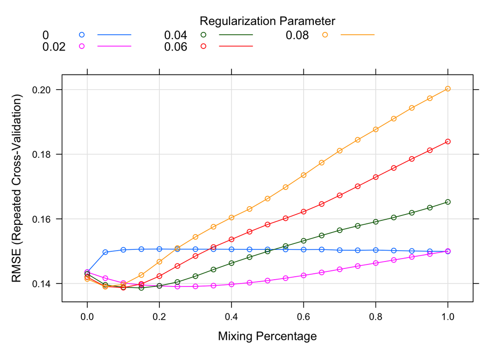

```r
# Plot the coefficients (non-zero) against log(lambda)
plot(fit.glmnet, xvar = "lambda", label = TRUE)
```

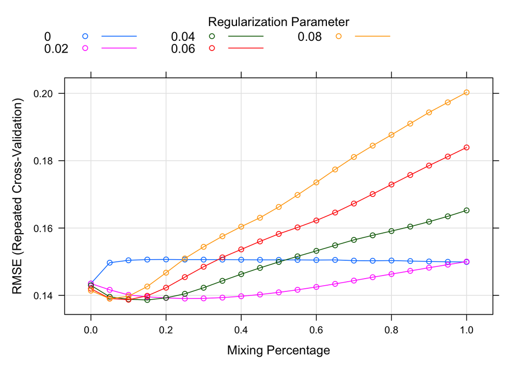

```r
# Plot the cross-validated mean squared error (CV RMSE) against log(lambda)
plot(fit.glmnet, xvar = "lambda", metric = "RMSE")
```

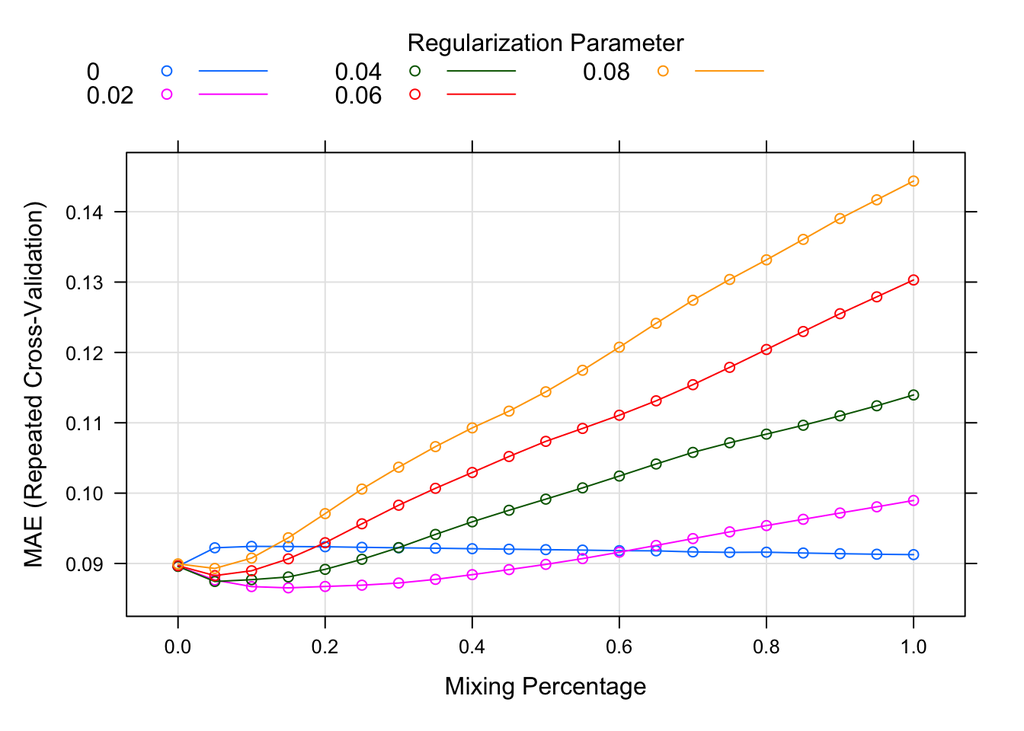

```r
# Plot the cross-validated mean absolute error (CV MAE) against log(lambda)
plot(fit.glmnet, xvar = "lambda", metric = "MAE")
```

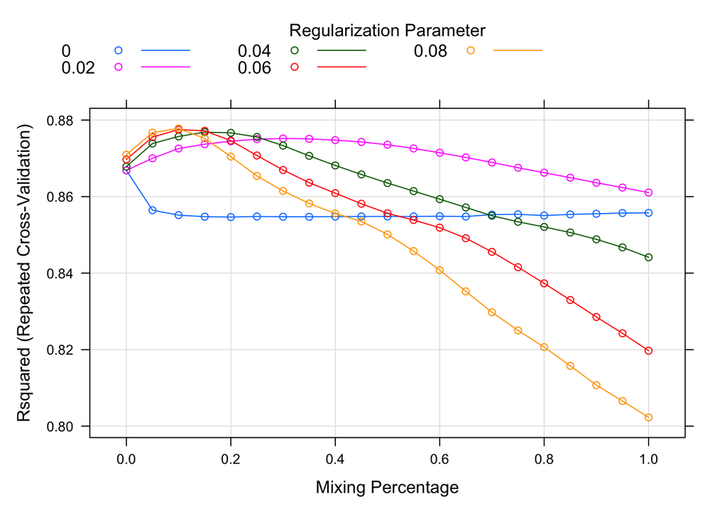

```r
# Plot the cross-validated R-squared against log(lambda)
plot(fit.glmnet, xvar = "lambda", metric = "Rsquared")
```

```r
# Perform prediction on the validate2 dataset using the regularized linear model
prediction <- predict(fit.glmnet, newdata = validate2, type = "raw")

# Calculate MSE for the regularized linear model
mse <- sqrt(mean((prediction - validate2$SalePrice)^2, na.rm = TRUE))
cat("MSE for the regularized linear model:", mse, "\n")
```

```
## MSE for the regularized linear model: 0.1323808
```

```r
# non-regularized model gived better mse score !!!!
```

The non-regularized model outperformed the regularized model in terms of mean squared error (MSE) score. This implies that the non-regularized model achieved better accuracy in predicting the target variable compared to the regularized model.

# BACKWARD MODEL SELECTION

In this step, we will perform backward model selection without considering the previously mentioned property combinations. The goal is to identify the most relevant features that significantly contribute to the predictive power of our model. By systematically removing variables from the model and evaluating the impact on model performance, we can determine the champion model.

Once we have identified the champion model, we will incorporate the property combinations mentioned earlier and assess if their inclusion improves the model’s performance. This analysis will help us determine whether the additional features derived from combining variables provide valuable insights and enhance the predictive capabilities of our model.

By conducting this two-step process, we can ensure that we first establish a strong baseline model and then evaluate the incremental benefit of incorporating the combined property variables. This approach will enable us to make informed decisions about feature selection and assess the potential improvement gained from the inclusion of these engineered features.

```r
# Here we will try backward model selection without considering above property.
#Then with the champion model,we will include above property and see if there is
#improvement or not

fit_lm_1 <- lm(SalePrice~GrLivArea+GarageCars+GarageArea+YrSold+SaleCondition+
                 Neighborhood+Fence+GarageQual+OverallQual+OverallCond+BsmtQual
               +KitchenQual+GarageFinish+GarageType+Foundation+FireplaceQu+
                 HeatingQC+BsmtFinType1+MasVnrType+Exterior1st+Exterior2nd+MSZoning+
             +TotalBsmtSF+X1stFlrSF+FullBath+YearBuilt+BsmtExposure+
               ExterQual+Condition1+I(LotArea^2)+
             Street+Condition2+LotConfig+LandSlope+RoofStyle+RoofMatl+
               BsmtFinSF2+BsmtUnfSF+X2ndFlrSF
            ,train_new)
# Print the summary of the model (fit_lm_1)
summary(fit_lm_1)
```

```
##
## Call:
## lm(formula = SalePrice ~ GrLivArea + GarageCars + GarageArea +
##     YrSold + SaleCondition + Neighborhood + Fence + GarageQual +
##     OverallQual + OverallCond + BsmtQual + KitchenQual + GarageFinish +
##     GarageType + Foundation + FireplaceQu + HeatingQC + BsmtFinType1 +
##     MasVnrType + Exterior1st + Exterior2nd + MSZoning + +TotalBsmtSF +
##     X1stFlrSF + FullBath + YearBuilt + BsmtExposure + ExterQual +
##     Condition1 + I(LotArea^2) + Street + Condition2 + LotConfig +
##     LandSlope + RoofStyle + RoofMatl + BsmtFinSF2 + BsmtUnfSF +
##     X2ndFlrSF, data = train_new)
##
## Residuals:
##      Min       1Q   Median       3Q      Max
## -0.69717 -0.05205  0.00604  0.05690  0.53153
##
## Coefficients: (6 not defined because of singularities)
##                        Estimate Std. Error t value Pr(>|t|)
## (Intercept)           9.471e+00  5.615e+00   1.687 0.091987 .
## GrLivArea             3.658e-01  5.013e-02   7.296 6.32e-13 ***
## GarageCars            2.690e-02  1.211e-02   2.221 0.026594 *
## GarageArea            6.798e-05  4.097e-05   1.659 0.097405 .
## YrSold               -3.635e-03  2.762e-03  -1.316 0.188478
## SaleConditionAdjLand  1.006e-01  6.624e-02   1.518 0.129237
## SaleConditionAlloca   2.288e-02  4.263e-02   0.537 0.591496
## SaleConditionFamily  -1.397e-02  3.227e-02  -0.433 0.665177
## SaleConditionNormal   3.970e-02  1.467e-02   2.706 0.006935 **
## SaleConditionPartial  6.999e-02  2.017e-02   3.470 0.000544 ***
## NeighborhoodBlueste  -3.317e-02  1.218e-01  -0.272 0.785359
## NeighborhoodBrDale   -4.105e-02  5.500e-02  -0.746 0.455711
## NeighborhoodBrkSide   2.580e-02  4.555e-02   0.566 0.571281
## NeighborhoodClearCr  -2.320e-02  4.781e-02  -0.485 0.627580
## NeighborhoodCollgCr  -2.064e-02  3.611e-02  -0.572 0.567749
## NeighborhoodCrawfor   1.120e-01  4.282e-02   2.616 0.009038 **
## NeighborhoodEdwards  -7.888e-02  4.004e-02  -1.970 0.049102 *
## NeighborhoodGilbert  -2.687e-02  3.810e-02  -0.705 0.480827
## NeighborhoodIDOTRR   -4.717e-02  5.325e-02  -0.886 0.375982
## NeighborhoodMeadowV  -1.069e-01  5.898e-02  -1.813 0.070144 .
## NeighborhoodMitchel  -6.479e-02  4.163e-02  -1.556 0.119989
## NeighborhoodNAmes    -2.198e-02  3.852e-02  -0.571 0.568453
```

[output cut: 131 more lines]

```
## RoofMatlCompShg       1.533e+00  1.297e-01  11.814  < 2e-16 ***
## RoofMatlMetal         1.668e-01  1.268e-01   1.316 0.188506
## RoofMatlRoll          1.439e+00  1.755e-01   8.203 7.70e-16 ***
## RoofMatlTar&Grv              NA         NA      NA       NA
## RoofMatlWdShake       1.591e+00  1.742e-01   9.137  < 2e-16 ***
## RoofMatlWdShngl       1.686e+00  1.369e-01  12.315  < 2e-16 ***
## BsmtFinSF2           -3.342e-03  2.165e-03  -1.543 0.123095
## BsmtUnfSF            -8.011e-03  2.876e-03  -2.786 0.005443 **
## X2ndFlrSF             3.782e-03  4.202e-03   0.900 0.368338
## ---
## Signif. codes:  0 '***' 0.001 '**' 0.01 '*' 0.05 '.' 0.1 ' ' 1
##
## Residual standard error: 0.11 on 938 degrees of freedom
## Multiple R-squared:  0.9331, Adjusted R-squared:  0.9221
## F-statistic: 84.46 on 155 and 938 DF,  p-value: < 2.2e-16
```

```r
#Removing LandSlope
fit_lm_2 <- lm(SalePrice~GrLivArea+GarageCars+GarageArea+YrSold+SaleCondition+
                 Neighborhood+Fence+GarageQual+OverallQual+OverallCond+BsmtQual+
                 KitchenQual+GarageFinish+GarageType+Foundation+FireplaceQu+
                 HeatingQC+BsmtFinType1+MasVnrType+Exterior1st+Exterior2nd+MSZoning+
               +TotalBsmtSF+X1stFlrSF+FullBath+YearBuilt+BsmtExposure+ExterQual
               +Condition1+I(LotArea^2)+Street+Condition2+LotConfig+RoofStyle+
                 RoofMatl+BsmtFinSF2+BsmtUnfSF+X2ndFlrSF
             ,train_new)
# Print the summary of the model (fit_lm_2)
summary(fit_lm_2)
```

```
##
## Call:
## lm(formula = SalePrice ~ GrLivArea + GarageCars + GarageArea +
##     YrSold + SaleCondition + Neighborhood + Fence + GarageQual +
##     OverallQual + OverallCond + BsmtQual + KitchenQual + GarageFinish +
##     GarageType + Foundation + FireplaceQu + HeatingQC + BsmtFinType1 +
##     MasVnrType + Exterior1st + Exterior2nd + MSZoning + +TotalBsmtSF +
##     X1stFlrSF + FullBath + YearBuilt + BsmtExposure + ExterQual +
##     Condition1 + I(LotArea^2) + Street + Condition2 + LotConfig +
##     RoofStyle + RoofMatl + BsmtFinSF2 + BsmtUnfSF + X2ndFlrSF,
##     data = train_new)
##
## Residuals:
##      Min       1Q   Median       3Q      Max
## -0.69525 -0.05261  0.00557  0.05575  0.53096
##
## Coefficients: (6 not defined because of singularities)
##                        Estimate Std. Error t value Pr(>|t|)
## (Intercept)           1.018e+01  5.624e+00   1.810 0.070544 .
## GrLivArea             3.656e-01  5.024e-02   7.278 7.15e-13 ***
## GarageCars            2.771e-02  1.214e-02   2.283 0.022655 *
## GarageArea            7.217e-05  4.105e-05   1.758 0.079091 .
## YrSold               -3.982e-03  2.767e-03  -1.439 0.150428
## SaleConditionAdjLand  1.109e-01  6.625e-02   1.673 0.094606 .
## SaleConditionAlloca   3.168e-02  4.262e-02   0.743 0.457460
## SaleConditionFamily  -1.223e-02  3.235e-02  -0.378 0.705549
## SaleConditionNormal   4.200e-02  1.467e-02   2.863 0.004284 **
## SaleConditionPartial  7.072e-02  2.021e-02   3.499 0.000489 ***
## NeighborhoodBlueste  -3.853e-02  1.221e-01  -0.316 0.752431
## NeighborhoodBrDale   -3.909e-02  5.516e-02  -0.709 0.478673
## NeighborhoodBrkSide   3.757e-02  4.544e-02   0.827 0.408569
## NeighborhoodClearCr  -2.449e-02  4.780e-02  -0.512 0.608456
## NeighborhoodCollgCr  -1.516e-02  3.615e-02  -0.419 0.675137
## NeighborhoodCrawfor   1.247e-01  4.264e-02   2.925 0.003532 **
## NeighborhoodEdwards  -7.089e-02  4.002e-02  -1.771 0.076837 .
## NeighborhoodGilbert  -2.072e-02  3.812e-02  -0.544 0.586821
## NeighborhoodIDOTRR   -3.716e-02  5.324e-02  -0.698 0.485426
## NeighborhoodMeadowV  -1.063e-01  5.915e-02  -1.798 0.072507 .
## NeighborhoodMitchel  -5.490e-02  4.158e-02  -1.320 0.187099
## NeighborhoodNAmes    -1.353e-02  3.843e-02  -0.352 0.724923
```

[output cut: 129 more lines]

```
## RoofMatlCompShg       1.533e+00  1.300e-01  11.795  < 2e-16 ***
## RoofMatlMetal         7.917e-02  1.228e-01   0.645 0.519353
## RoofMatlRoll          1.441e+00  1.759e-01   8.192 8.34e-16 ***
## RoofMatlTar&Grv              NA         NA      NA       NA
## RoofMatlWdShake       1.597e+00  1.745e-01   9.151  < 2e-16 ***
## RoofMatlWdShngl       1.691e+00  1.371e-01  12.331  < 2e-16 ***
## BsmtFinSF2           -3.448e-03  2.171e-03  -1.588 0.112553
## BsmtUnfSF            -7.863e-03  2.879e-03  -2.731 0.006429 **
## X2ndFlrSF             3.607e-03  4.208e-03   0.857 0.391607
## ---
## Signif. codes:  0 '***' 0.001 '**' 0.01 '*' 0.05 '.' 0.1 ' ' 1
##
## Residual standard error: 0.1103 on 940 degrees of freedom
## Multiple R-squared:  0.9326, Adjusted R-squared:  0.9216
## F-statistic: 85.01 on 153 and 940 DF,  p-value: < 2.2e-16
```

```r
#Removing RoofMat1
fit_lm_3 <- lm(SalePrice~GrLivArea+GarageCars+GarageArea+YrSold+SaleCondition+
                 Neighborhood+Fence+GarageQual+OverallQual+OverallCond+BsmtQual+
                 KitchenQual+GarageFinish+GarageType+Foundation+
                 FireplaceQu+HeatingQC+BsmtFinType1+MasVnrType+Exterior1st+
                 Exterior2nd+MSZoning+TotalBsmtSF+X1stFlrSF+FullBath+YearBuilt+
                 BsmtExposure+ExterQual+Condition1+I(LotArea^2)+Street+Condition2+
                 LotConfig+RoofStyle+BsmtFinSF2+BsmtUnfSF+X2ndFlrSF
               ,train_new)
# Print the summary of the model (fit_lm_3)
summary(fit_lm_3)
```

```
##
## Call:
## lm(formula = SalePrice ~ GrLivArea + GarageCars + GarageArea +
##     YrSold + SaleCondition + Neighborhood + Fence + GarageQual +
##     OverallQual + OverallCond + BsmtQual + KitchenQual + GarageFinish +
##     GarageType + Foundation + FireplaceQu + HeatingQC + BsmtFinType1 +
##     MasVnrType + Exterior1st + Exterior2nd + MSZoning + TotalBsmtSF +
##     X1stFlrSF + FullBath + YearBuilt + BsmtExposure + ExterQual +
##     Condition1 + I(LotArea^2) + Street + Condition2 + LotConfig +
##     RoofStyle + BsmtFinSF2 + BsmtUnfSF + X2ndFlrSF, data = train_new)
##
## Residuals:
##      Min       1Q   Median       3Q      Max
## -1.12243 -0.05598  0.00623  0.05587  0.49381
##
## Coefficients: (5 not defined because of singularities)
##                        Estimate Std. Error t value Pr(>|t|)
## (Intercept)           1.409e+01  6.019e+00   2.341 0.019419 *
## GrLivArea             4.120e-01  5.369e-02   7.674 4.15e-14 ***
## GarageCars            6.074e-02  1.271e-02   4.779 2.04e-06 ***
## GarageArea           -3.867e-05  4.299e-05  -0.899 0.368624
## YrSold               -5.125e-03  2.965e-03  -1.729 0.084223 .
## SaleConditionAdjLand  1.199e-01  7.113e-02   1.686 0.092188 .
## SaleConditionAlloca   4.291e-02  4.584e-02   0.936 0.349472
## SaleConditionFamily  -6.782e-03  3.479e-02  -0.195 0.845475
## SaleConditionNormal   4.568e-02  1.575e-02   2.899 0.003829 **
## SaleConditionPartial  6.457e-02  2.174e-02   2.970 0.003049 **
## NeighborhoodBlueste  -6.752e-02  1.313e-01  -0.514 0.607266
## NeighborhoodBrDale   -5.512e-02  5.927e-02  -0.930 0.352599
## NeighborhoodBrkSide   3.196e-02  4.884e-02   0.654 0.513047
## NeighborhoodClearCr   1.255e-02  5.110e-02   0.246 0.806023
## NeighborhoodCollgCr   8.103e-03  3.880e-02   0.209 0.834616
## NeighborhoodCrawfor   1.266e-01  4.583e-02   2.762 0.005852 **
## NeighborhoodEdwards  -8.048e-02  4.301e-02  -1.871 0.061605 .
## NeighborhoodGilbert  -9.099e-03  4.098e-02  -0.222 0.824331
## NeighborhoodIDOTRR   -4.000e-02  5.718e-02  -0.699 0.484433
## NeighborhoodMeadowV  -1.277e-01  6.355e-02  -2.010 0.044707 *
## NeighborhoodMitchel  -4.724e-02  4.468e-02  -1.058 0.290553
## NeighborhoodNAmes    -6.557e-03  4.130e-02  -0.159 0.873904
## NeighborhoodNoRidge   1.293e-01  4.496e-02   2.877 0.004111 **
```

[output cut: 122 more lines]

```
## LotConfigFR3         -1.558e-01  8.814e-02  -1.768 0.077465 .
## LotConfigInside      -1.869e-02  1.050e-02  -1.780 0.075359 .
## RoofStyleGable        1.820e-02  4.618e-02   0.394 0.693658
## RoofStyleGambrel     -2.866e-02  6.324e-02  -0.453 0.650546
## RoofStyleHip          3.111e-02  4.729e-02   0.658 0.510764
## RoofStyleMansard      1.763e-01  1.483e-01   1.189 0.234807
## BsmtFinSF2           -3.002e-03  2.329e-03  -1.289 0.197726
## BsmtUnfSF            -7.438e-03  3.077e-03  -2.417 0.015833 *
## X2ndFlrSF            -3.097e-03  4.478e-03  -0.692 0.489358
## ---
## Signif. codes:  0 '***' 0.001 '**' 0.01 '*' 0.05 '.' 0.1 ' ' 1
##
## Residual standard error: 0.1187 on 945 degrees of freedom
## Multiple R-squared:  0.9216, Adjusted R-squared:  0.9093
## F-statistic: 75.03 on 148 and 945 DF,  p-value: < 2.2e-16
```

```r
#Removing Condition2
fit_lm_4 <- lm(SalePrice~GrLivArea+GarageCars+GarageArea+YrSold+SaleCondition+
                 Neighborhood+Fence+GarageQual+
                 OverallQual+OverallCond+BsmtQual+KitchenQual+GarageFinish+
                 GarageType+Foundation+FireplaceQu+HeatingQC+BsmtFinType1+
                 MasVnrType+Exterior1st+Exterior2nd+MSZoning+TotalBsmtSF+
                 X1stFlrSF+FullBath+YearBuilt+BsmtExposure+ExterQual+
                 Condition1+I(LotArea^2)+Street+LotConfig+RoofStyle+
                 BsmtFinSF2+BsmtUnfSF+X2ndFlrSF
               ,train_new)
# Print the summary of the model (fit_lm_4)
summary(fit_lm_4)
```

```
##
## Call:
## lm(formula = SalePrice ~ GrLivArea + GarageCars + GarageArea +
##     YrSold + SaleCondition + Neighborhood + Fence + GarageQual +
##     OverallQual + OverallCond + BsmtQual + KitchenQual + GarageFinish +
##     GarageType + Foundation + FireplaceQu + HeatingQC + BsmtFinType1 +
##     MasVnrType + Exterior1st + Exterior2nd + MSZoning + TotalBsmtSF +
##     X1stFlrSF + FullBath + YearBuilt + BsmtExposure + ExterQual +
##     Condition1 + I(LotArea^2) + Street + LotConfig + RoofStyle +
##     BsmtFinSF2 + BsmtUnfSF + X2ndFlrSF, data = train_new)
##
## Residuals:
##      Min       1Q   Median       3Q      Max
## -1.08354 -0.05468  0.00588  0.05737  0.40870
##
## Coefficients: (5 not defined because of singularities)
##                        Estimate Std. Error t value Pr(>|t|)
## (Intercept)          13.1831691  6.1594374   2.140 0.032583 *
## GrLivArea             0.4210052  0.0548843   7.671 4.22e-14 ***
## GarageCars            0.0623182  0.0129647   4.807 1.78e-06 ***
## GarageArea           -0.0000417  0.0000436  -0.957 0.339060
## YrSold               -0.0043951  0.0030337  -1.449 0.147736
## SaleConditionAdjLand  0.1159397  0.0728444   1.592 0.111805
## SaleConditionAlloca   0.0387489  0.0468949   0.826 0.408846
## SaleConditionFamily  -0.0062741  0.0356947  -0.176 0.860511
## SaleConditionNormal   0.0479577  0.0161360   2.972 0.003032 **
## SaleConditionPartial  0.0589045  0.0222885   2.643 0.008357 **
## NeighborhoodBlueste  -0.0907429  0.1346961  -0.674 0.500675
## NeighborhoodBrDale   -0.0661362  0.0607375  -1.089 0.276481
## NeighborhoodBrkSide   0.0124904  0.0497002   0.251 0.801625
## NeighborhoodClearCr   0.0088990  0.0524000   0.170 0.865182
## NeighborhoodCollgCr   0.0098692  0.0397863   0.248 0.804145
## NeighborhoodCrawfor   0.1192603  0.0469703   2.539 0.011274 *
## NeighborhoodEdwards  -0.0960258  0.0440989  -2.178 0.029688 *
## NeighborhoodGilbert  -0.0100333  0.0420259  -0.239 0.811359
## NeighborhoodIDOTRR   -0.0603354  0.0584452  -1.032 0.302174
## NeighborhoodMeadowV  -0.1129864  0.0650133  -1.738 0.082553 .
## NeighborhoodMitchel  -0.0463932  0.0458303  -1.012 0.311661
## NeighborhoodNAmes    -0.0114469  0.0423834  -0.270 0.787158
## NeighborhoodNoRidge   0.1319763  0.0461361   2.861 0.004321 **
```

[output cut: 116 more lines]

```
## LotConfigFR3         -0.1535992  0.0904606  -1.698 0.089841 .
## LotConfigInside      -0.0174910  0.0107093  -1.633 0.102747
## RoofStyleGable        0.0157528  0.0473625   0.333 0.739509
## RoofStyleGambrel     -0.0427828  0.0648562  -0.660 0.509634
## RoofStyleHip          0.0263428  0.0484968   0.543 0.587129
## RoofStyleMansard      0.1579223  0.1521991   1.038 0.299718
## BsmtFinSF2           -0.0030173  0.0023860  -1.265 0.206328
## BsmtUnfSF            -0.0077488  0.0031537  -2.457 0.014188 *
## X2ndFlrSF            -0.0038554  0.0045834  -0.841 0.400463
## ---
## Signif. codes:  0 '***' 0.001 '**' 0.01 '*' 0.05 '.' 0.1 ' ' 1
##
## Residual standard error: 0.1218 on 951 degrees of freedom
## Multiple R-squared:  0.9168, Adjusted R-squared:  0.9044
## F-statistic:  73.8 on 142 and 951 DF,  p-value: < 2.2e-16
```

```r
#Removing Street
fit_lm_5 <- lm(SalePrice~GrLivArea+GarageCars+GarageArea+YrSold+SaleCondition+
                 Neighborhood+Fence+GarageQual+OverallQual+OverallCond+BsmtQual+
                 KitchenQual+GarageFinish+GarageType+Foundation+
                 FireplaceQu+HeatingQC+BsmtFinType1+MasVnrType+Exterior1st+
                 Exterior2nd+MSZoning+TotalBsmtSF+X1stFlrSF+FullBath+YearBuilt+
                 BsmtExposure+ExterQual+Condition1+I(LotArea^2)+
                 LotConfig+RoofStyle+BsmtFinSF2+BsmtUnfSF+X2ndFlrSF
               ,train_new)
# Print the summary of the model (fit_lm_5)
summary(fit_lm_5)
```

```
##
## Call:
## lm(formula = SalePrice ~ GrLivArea + GarageCars + GarageArea +
##     YrSold + SaleCondition + Neighborhood + Fence + GarageQual +
##     OverallQual + OverallCond + BsmtQual + KitchenQual + GarageFinish +
##     GarageType + Foundation + FireplaceQu + HeatingQC + BsmtFinType1 +
##     MasVnrType + Exterior1st + Exterior2nd + MSZoning + TotalBsmtSF +
##     X1stFlrSF + FullBath + YearBuilt + BsmtExposure + ExterQual +
##     Condition1 + I(LotArea^2) + LotConfig + RoofStyle + BsmtFinSF2 +
##     BsmtUnfSF + X2ndFlrSF, data = train_new)
##
## Residuals:
##      Min       1Q   Median       3Q      Max
## -1.07867 -0.05352  0.00659  0.05819  0.40577
##
## Coefficients: (5 not defined because of singularities)
##                        Estimate Std. Error t value Pr(>|t|)
## (Intercept)           1.347e+01  6.165e+00   2.185 0.029154 *
## GrLivArea             4.361e-01  5.432e-02   8.029 2.88e-15 ***
## GarageCars            6.176e-02  1.298e-02   4.759 2.25e-06 ***
## GarageArea           -4.377e-05  4.364e-05  -1.003 0.316082
## YrSold               -4.444e-03  3.037e-03  -1.463 0.143752
## SaleConditionAdjLand  1.096e-01  7.285e-02   1.504 0.132893
## SaleConditionAlloca   2.563e-02  4.640e-02   0.552 0.580852
## SaleConditionFamily  -7.016e-03  3.574e-02  -0.196 0.844391
## SaleConditionNormal   4.684e-02  1.614e-02   2.901 0.003802 **
## SaleConditionPartial  5.868e-02  2.232e-02   2.629 0.008691 **
## NeighborhoodBlueste  -9.196e-02  1.349e-01  -0.682 0.495462
## NeighborhoodBrDale   -6.726e-02  6.081e-02  -1.106 0.268985
## NeighborhoodBrkSide   1.759e-02  4.968e-02   0.354 0.723338
## NeighborhoodClearCr   1.628e-02  5.231e-02   0.311 0.755628
## NeighborhoodCollgCr   1.445e-02  3.976e-02   0.363 0.716410
## NeighborhoodCrawfor   1.238e-01  4.696e-02   2.635 0.008544 **
## NeighborhoodEdwards  -9.045e-02  4.405e-02  -2.053 0.040305 *
## NeighborhoodGilbert  -4.547e-03  4.197e-02  -0.108 0.913749
## NeighborhoodIDOTRR   -5.752e-02  5.850e-02  -0.983 0.325693
## NeighborhoodMeadowV  -1.142e-01  6.509e-02  -1.754 0.079714 .
## NeighborhoodMitchel  -3.997e-02  4.575e-02  -0.874 0.382534
## NeighborhoodNAmes    -6.354e-03  4.234e-02  -0.150 0.880751
## NeighborhoodNoRidge   1.368e-01  4.612e-02   2.966 0.003090 **
```

[output cut: 115 more lines]

```
## LotConfigFR3         -1.522e-01  9.057e-02  -1.681 0.093154 .
## LotConfigInside      -1.714e-02  1.072e-02  -1.599 0.110214
## RoofStyleGable        1.320e-02  4.740e-02   0.278 0.780700
## RoofStyleGambrel     -4.227e-02  6.493e-02  -0.651 0.515225
## RoofStyleHip          2.460e-02  4.855e-02   0.507 0.612413
## RoofStyleMansard      1.551e-01  1.524e-01   1.018 0.309035
## BsmtFinSF2           -3.284e-03  2.384e-03  -1.377 0.168714
## BsmtUnfSF            -7.938e-03  3.156e-03  -2.515 0.012052 *
## X2ndFlrSF            -4.976e-03  4.548e-03  -1.094 0.274151
## ---
## Signif. codes:  0 '***' 0.001 '**' 0.01 '*' 0.05 '.' 0.1 ' ' 1
##
## Residual standard error: 0.122 on 952 degrees of freedom
## Multiple R-squared:  0.9165, Adjusted R-squared:  0.9041
## F-statistic: 74.12 on 141 and 952 DF,  p-value: < 2.2e-16
```

```r
#Removing ExterQual
fit_lm_6 <- lm(SalePrice~GrLivArea+GarageCars+GarageArea+YrSold+SaleCondition+
                 Neighborhood+Fence+GarageQual+OverallQual+OverallCond+BsmtQual+
                 KitchenQual+GarageFinish+GarageType+Foundation+FireplaceQu+
                 HeatingQC+BsmtFinType1+MasVnrType+Exterior1st+Exterior2nd+
                 MSZoning+TotalBsmtSF+X1stFlrSF+FullBath+YearBuilt+BsmtExposure+
                 Condition1+I(LotArea^2)+LotConfig+RoofStyle+BsmtFinSF2+BsmtUnfSF
               +X2ndFlrSF,train_new)
# Print the summary of the model (fit_lm_6)
summary(fit_lm_6)
```

```
##
## Call:
## lm(formula = SalePrice ~ GrLivArea + GarageCars + GarageArea +
##     YrSold + SaleCondition + Neighborhood + Fence + GarageQual +
##     OverallQual + OverallCond + BsmtQual + KitchenQual + GarageFinish +
##     GarageType + Foundation + FireplaceQu + HeatingQC + BsmtFinType1 +
##     MasVnrType + Exterior1st + Exterior2nd + MSZoning + TotalBsmtSF +
##     X1stFlrSF + FullBath + YearBuilt + BsmtExposure + Condition1 +
##     I(LotArea^2) + LotConfig + RoofStyle + BsmtFinSF2 + BsmtUnfSF +
##     X2ndFlrSF, data = train_new)
##
## Residuals:
##      Min       1Q   Median       3Q      Max
## -1.08723 -0.05303  0.00495  0.05824  0.40577
##
## Coefficients: (5 not defined because of singularities)
##                        Estimate Std. Error t value Pr(>|t|)
## (Intercept)           1.420e+01  6.130e+00   2.316 0.020788 *
## GrLivArea             4.343e-01  5.417e-02   8.016 3.18e-15 ***
## GarageCars            6.268e-02  1.295e-02   4.842 1.50e-06 ***
## GarageArea           -4.878e-05  4.345e-05  -1.123 0.261842
## YrSold               -4.765e-03  3.022e-03  -1.577 0.115127
## SaleConditionAdjLand  1.105e-01  7.280e-02   1.518 0.129298
## SaleConditionAlloca   2.431e-02  4.634e-02   0.525 0.600035
## SaleConditionFamily  -6.791e-03  3.571e-02  -0.190 0.849226
## SaleConditionNormal   4.711e-02  1.613e-02   2.921 0.003569 **
## SaleConditionPartial  5.804e-02  2.227e-02   2.606 0.009293 **
## NeighborhoodBlueste  -8.672e-02  1.346e-01  -0.644 0.519546
## NeighborhoodBrDale   -6.461e-02  6.063e-02  -1.066 0.286860
## NeighborhoodBrkSide   1.705e-02  4.950e-02   0.344 0.730638
## NeighborhoodClearCr   1.962e-02  5.214e-02   0.376 0.706772
## NeighborhoodCollgCr   1.602e-02  3.967e-02   0.404 0.686403
## NeighborhoodCrawfor   1.246e-01  4.682e-02   2.661 0.007923 **
## NeighborhoodEdwards  -8.903e-02  4.390e-02  -2.028 0.042825 *
## NeighborhoodGilbert  -3.506e-03  4.179e-02  -0.084 0.933160
## NeighborhoodIDOTRR   -5.601e-02  5.833e-02  -0.960 0.337147
## NeighborhoodMeadowV  -1.062e-01  6.473e-02  -1.640 0.101267
## NeighborhoodMitchel  -3.584e-02  4.546e-02  -0.788 0.430627
## NeighborhoodNAmes    -3.971e-03  4.212e-02  -0.094 0.924892
## NeighborhoodNoRidge   1.371e-01  4.607e-02   2.976 0.002992 **
```

[output cut: 112 more lines]

```
## LotConfigFR3         -1.440e-01  9.013e-02  -1.598 0.110473
## LotConfigInside      -1.758e-02  1.070e-02  -1.643 0.100741
## RoofStyleGable        1.078e-02  4.732e-02   0.228 0.819830
## RoofStyleGambrel     -4.576e-02  6.481e-02  -0.706 0.480311
## RoofStyleHip          2.011e-02  4.835e-02   0.416 0.677606
## RoofStyleMansard      1.535e-01  1.522e-01   1.008 0.313526
## BsmtFinSF2           -3.451e-03  2.380e-03  -1.450 0.147292
## BsmtUnfSF            -8.214e-03  3.144e-03  -2.612 0.009132 **
## X2ndFlrSF            -4.716e-03  4.532e-03  -1.041 0.298238
## ---
## Signif. codes:  0 '***' 0.001 '**' 0.01 '*' 0.05 '.' 0.1 ' ' 1
##
## Residual standard error: 0.1219 on 955 degrees of freedom
## Multiple R-squared:  0.9163, Adjusted R-squared:  0.9043
## F-statistic:  75.8 on 138 and 955 DF,  p-value: < 2.2e-16
```

```r
#Removing Exterior2nd, FullBath
fit_lm_7 <- lm(SalePrice~GrLivArea+GarageCars+GarageArea+YrSold+SaleCondition+
                 Neighborhood+Fence+GarageQual+OverallQual+OverallCond+BsmtQual+
                 KitchenQual+GarageFinish+GarageType+Foundation+
                 FireplaceQu+HeatingQC+BsmtFinType1+MasVnrType+Exterior1st+
                 MSZoning+TotalBsmtSF+X1stFlrSF+YearBuilt+BsmtExposure+
                 Condition1+I(LotArea^2)+LotConfig+RoofStyle+BsmtFinSF2+
                 BsmtUnfSF+X2ndFlrSF
               ,train_new)
# Print the summary of the model (fit_lm_7)
summary(fit_lm_7)
```

```
##
## Call:
## lm(formula = SalePrice ~ GrLivArea + GarageCars + GarageArea +
##     YrSold + SaleCondition + Neighborhood + Fence + GarageQual +
##     OverallQual + OverallCond + BsmtQual + KitchenQual + GarageFinish +
##     GarageType + Foundation + FireplaceQu + HeatingQC + BsmtFinType1 +
##     MasVnrType + Exterior1st + MSZoning + TotalBsmtSF + X1stFlrSF +
##     YearBuilt + BsmtExposure + Condition1 + I(LotArea^2) + LotConfig +
##     RoofStyle + BsmtFinSF2 + BsmtUnfSF + X2ndFlrSF, data = train_new)
##
## Residuals:
##      Min       1Q   Median       3Q      Max
## -1.11876 -0.05239  0.00352  0.05792  0.38692
##
## Coefficients: (3 not defined because of singularities)
##                        Estimate Std. Error t value Pr(>|t|)
## (Intercept)           1.420e+01  6.106e+00   2.326 0.020233 *
## GrLivArea             4.367e-01  5.257e-02   8.307 3.28e-16 ***
## GarageCars            6.135e-02  1.286e-02   4.771 2.12e-06 ***
## GarageArea           -3.725e-05  4.306e-05  -0.865 0.387270
## YrSold               -4.799e-03  3.009e-03  -1.595 0.111008
## SaleConditionAdjLand  1.236e-01  7.026e-02   1.758 0.078985 .
## SaleConditionAlloca   1.458e-02  4.572e-02   0.319 0.749858
## SaleConditionFamily  -9.815e-05  3.547e-02  -0.003 0.997793
## SaleConditionNormal   4.916e-02  1.592e-02   3.088 0.002072 **
## SaleConditionPartial  6.231e-02  2.202e-02   2.830 0.004758 **
## NeighborhoodBlueste  -9.185e-02  1.344e-01  -0.683 0.494549
## NeighborhoodBrDale   -6.141e-02  6.027e-02  -1.019 0.308456
## NeighborhoodBrkSide   1.070e-02  4.929e-02   0.217 0.828128
## NeighborhoodClearCr   1.667e-02  5.197e-02   0.321 0.748464
## NeighborhoodCollgCr   1.686e-02  3.957e-02   0.426 0.670109
## NeighborhoodCrawfor   1.179e-01  4.656e-02   2.532 0.011508 *
## NeighborhoodEdwards  -8.733e-02  4.374e-02  -1.997 0.046153 *
## NeighborhoodGilbert   5.995e-04  4.166e-02   0.014 0.988521
## NeighborhoodIDOTRR   -6.434e-02  5.816e-02  -1.106 0.268861
## NeighborhoodMeadowV  -1.040e-01  6.434e-02  -1.617 0.106259
## NeighborhoodMitchel  -3.213e-02  4.505e-02  -0.713 0.475868
## NeighborhoodNAmes    -8.404e-03  4.187e-02  -0.201 0.840943
## NeighborhoodNoRidge   1.402e-01  4.572e-02   3.067 0.002221 **
## NeighborhoodNPkVill   8.391e-03  6.207e-02   0.135 0.892489
```

[output cut: 96 more lines]

```
## LotConfigFR3         -1.329e-01  9.011e-02  -1.474 0.140693
## LotConfigInside      -1.591e-02  1.064e-02  -1.495 0.135155
## RoofStyleGable        1.390e-02  4.711e-02   0.295 0.767998
## RoofStyleGambrel     -3.843e-02  6.432e-02  -0.597 0.550355
## RoofStyleHip          2.122e-02  4.809e-02   0.441 0.659091
## RoofStyleMansard      1.535e-01  1.507e-01   1.018 0.308857
## BsmtFinSF2           -3.516e-03  2.356e-03  -1.492 0.135915
## BsmtUnfSF            -7.459e-03  3.106e-03  -2.401 0.016519 *
## X2ndFlrSF            -4.836e-03  4.494e-03  -1.076 0.282163
## ---
## Signif. codes:  0 '***' 0.001 '**' 0.01 '*' 0.05 '.' 0.1 ' ' 1
##
## Residual standard error: 0.122 on 968 degrees of freedom
## Multiple R-squared:  0.9151, Adjusted R-squared:  0.9041
## F-statistic: 83.43 on 125 and 968 DF,  p-value: < 2.2e-16
```

FEATURE ENGINEERING

Feature engineering is an essential step in the data analysis process, where new variables are created by combining existing ones to capture additional information or create more meaningful features. In this project, we propose the following variable combinations:

- GarageCars ve GarageArea
- TotalBsmtSF ve X1stFlrSF
- GrLivArea ve TotRmsAbvGrd
- GrLivArea ve FullBath
- LotFrontage ve LotArea

```r
fit_lm_8 <- lm(SalePrice~GrLivArea+I(GarageCars+GarageArea)+YrSold+
                 SaleCondition+Neighborhood+Fence+GarageQual+
                 OverallQual+OverallCond+BsmtQual+KitchenQual+GarageFinish+
                 GarageType+Foundation+FireplaceQu+HeatingQC+BsmtFinType1+
                 MasVnrType+Exterior1st+MSZoning+TotalBsmtSF+X1stFlrSF+
                 YearBuilt+BsmtExposure+Condition1+I(LotArea^2)+
                 LotConfig+RoofStyle+BsmtFinSF2+BsmtUnfSF+X2ndFlrSF
               ,train_new)
# Print the summary of the model (fit_lm_8)
summary(fit_lm_8)
```

```
##
## Call:
## lm(formula = SalePrice ~ GrLivArea + I(GarageCars + GarageArea) +
##     YrSold + SaleCondition + Neighborhood + Fence + GarageQual +
##     OverallQual + OverallCond + BsmtQual + KitchenQual + GarageFinish +
##     GarageType + Foundation + FireplaceQu + HeatingQC + BsmtFinType1 +
##     MasVnrType + Exterior1st + MSZoning + TotalBsmtSF + X1stFlrSF +
##     YearBuilt + BsmtExposure + Condition1 + I(LotArea^2) + LotConfig +
##     RoofStyle + BsmtFinSF2 + BsmtUnfSF + X2ndFlrSF, data = train_new)
##
## Residuals:
##      Min       1Q   Median       3Q      Max
## -1.23464 -0.05359  0.00325  0.06053  0.38898
##
## Coefficients: (3 not defined because of singularities)
##                              Estimate Std. Error t value Pr(>|t|)
## (Intercept)                15.0114678  6.1719155   2.432 0.015187 *
## GrLivArea                   0.4617614  0.0528871   8.731  < 2e-16 ***
## I(GarageCars + GarageArea)  0.0001023  0.0000319   3.208 0.001379 **
## YrSold                     -0.0052247  0.0030408  -1.718 0.086080 .
## SaleConditionAdjLand        0.1166463  0.0710271   1.642 0.100857
## SaleConditionAlloca         0.0354268  0.0460117   0.770 0.441516
## SaleConditionFamily        -0.0058419  0.0358440  -0.163 0.870566
## SaleConditionNormal         0.0475445  0.0160932   2.954 0.003209 **
## SaleConditionPartial        0.0578371  0.0222472   2.600 0.009471 **
## NeighborhoodBlueste        -0.1039645  0.1358897  -0.765 0.444419
## NeighborhoodBrDale         -0.0913401  0.0606039  -1.507 0.132094
## NeighborhoodBrkSide        -0.0069400  0.0496959  -0.140 0.888966
## NeighborhoodClearCr         0.0036089  0.0524768   0.069 0.945186
## NeighborhoodCollgCr        -0.0013374  0.0398183  -0.034 0.973213
## NeighborhoodCrawfor         0.1034129  0.0469798   2.201 0.027956 *
## NeighborhoodEdwards        -0.1091532  0.0439831  -2.482 0.013244 *
## NeighborhoodGilbert        -0.0012863  0.0421189  -0.031 0.975643
## NeighborhoodIDOTRR         -0.1021655  0.0582568  -1.754 0.079796 .
## NeighborhoodMeadowV        -0.1373707  0.0646706  -2.124 0.033909 *
## NeighborhoodMitchel        -0.0397425  0.0455273  -0.873 0.382913
## NeighborhoodNAmes          -0.0251858  0.0421809  -0.597 0.550587
## NeighborhoodNoRidge         0.1332887  0.0462078   2.885 0.004007 **
## NeighborhoodNPkVill         0.0144652  0.0627464   0.231 0.817725
## NeighborhoodNridgHt         0.1131686  0.0424999   2.663 0.007878 **
```

[output cut: 95 more lines]

```
## LotConfigFR3               -0.1341923  0.0911114  -1.473 0.141120
## LotConfigInside            -0.0175639  0.0107493  -1.634 0.102593
## RoofStyleGable              0.0141256  0.0476369   0.297 0.766891
## RoofStyleGambrel           -0.0416767  0.0650369  -0.641 0.521793
## RoofStyleHip                0.0232531  0.0486195   0.478 0.632568
## RoofStyleMansard            0.1523211  0.1524149   0.999 0.317858
## BsmtFinSF2                 -0.0038036  0.0023811  -1.597 0.110504
## BsmtUnfSF                  -0.0064215  0.0031330  -2.050 0.040669 *
## X2ndFlrSF                  -0.0064816  0.0045307  -1.431 0.152866
## ---
## Signif. codes:  0 '***' 0.001 '**' 0.01 '*' 0.05 '.' 0.1 ' ' 1
##
## Residual standard error: 0.1234 on 969 degrees of freedom
## Multiple R-squared:  0.9131, Adjusted R-squared:  0.9019
## F-statistic: 82.08 on 124 and 969 DF,  p-value: < 2.2e-16
```

After performing backward model selection, we have determined that the 7th model is the best model among the selected models. This model likely includes a subset of variables that have the most significant impact on predicting the target variable.

Now, our next step is to compare the performance of the 7th model with a model that includes almost all variables. By excluding some variables from the nearly complete model, we can assess the effect of variable reduction on the model’s predictive accuracy.

By conducting this comparison, we can determine whether the inclusion of additional variables in the nearly complete model significantly improves the model’s performance compared to the 7th model, or if the 7th model’s simplicity and reduced set of variables still provide satisfactory predictive results.

```r
# Since we now want to look mse error on validation set and see if there is overfit
#or not compared to the model that we used all the varaibles, we now extracting some
#of the problematic variables as above.

fit_lm_7_prime <- lm(SalePrice~GrLivArea+GarageCars+GarageArea+YrSold+SaleCondition
                     +Neighborhood+Fence+GarageQual+
                 OverallQual+OverallCond+BsmtQual+KitchenQual+GarageFinish+GarageType
                 +Foundation+FireplaceQu+HeatingQC+BsmtFinType1+MasVnrType+Exterior1st+
                   MSZoning+TotalBsmtSF+X1stFlrSF+YearBuilt+BsmtExposure+Condition1+
                   I(LotArea^2)+LotConfig+BsmtFinSF2+BsmtUnfSF+X2ndFlrSF
               ,train_new2)
# Print the summary of the model (fit_lm_7)
summary(fit_lm_7_prime)
```

```
##
## Call:
## lm(formula = SalePrice ~ GrLivArea + GarageCars + GarageArea +
##     YrSold + SaleCondition + Neighborhood + Fence + GarageQual +
##     OverallQual + OverallCond + BsmtQual + KitchenQual + GarageFinish +
##     GarageType + Foundation + FireplaceQu + HeatingQC + BsmtFinType1 +
##     MasVnrType + Exterior1st + MSZoning + TotalBsmtSF + X1stFlrSF +
##     YearBuilt + BsmtExposure + Condition1 + I(LotArea^2) + LotConfig +
##     BsmtFinSF2 + BsmtUnfSF + X2ndFlrSF, data = train_new2)
##
## Residuals:
##      Min       1Q   Median       3Q      Max
## -1.11813 -0.05246  0.00439  0.05815  0.38613
##
## Coefficients: (3 not defined because of singularities)
##                        Estimate Std. Error t value Pr(>|t|)
## (Intercept)           1.418e+01  6.101e+00   2.325 0.020283 *
## GrLivArea             4.359e-01  5.239e-02   8.320 2.95e-16 ***
## GarageCars            6.191e-02  1.284e-02   4.820 1.66e-06 ***
## GarageArea           -3.545e-05  4.297e-05  -0.825 0.409511
## YrSold               -4.822e-03  3.006e-03  -1.604 0.108957
## SaleConditionAdjLand  1.033e-01  6.823e-02   1.515 0.130214
## SaleConditionAlloca   1.381e-02  4.562e-02   0.303 0.762219
## SaleConditionFamily   2.940e-04  3.541e-02   0.008 0.993376
## SaleConditionNormal   4.874e-02  1.586e-02   3.073 0.002175 **
## SaleConditionPartial  6.141e-02  2.198e-02   2.794 0.005305 **
## NeighborhoodBlueste  -9.531e-02  1.343e-01  -0.710 0.478117
## NeighborhoodBrDale   -6.350e-02  6.019e-02  -1.055 0.291712
## NeighborhoodBrkSide   7.876e-03  4.920e-02   0.160 0.872857
## NeighborhoodClearCr   1.527e-02  5.132e-02   0.298 0.766070
## NeighborhoodCollgCr   1.756e-02  3.953e-02   0.444 0.657047
## NeighborhoodCrawfor   1.175e-01  4.651e-02   2.526 0.011706 *
## NeighborhoodEdwards  -8.688e-02  4.367e-02  -1.990 0.046916 *
## NeighborhoodGilbert   1.806e-03  4.162e-02   0.043 0.965388
## NeighborhoodIDOTRR   -6.370e-02  5.812e-02  -1.096 0.273328
## NeighborhoodMeadowV  -1.048e-01  6.424e-02  -1.631 0.103259
## NeighborhoodMitchel  -3.160e-02  4.501e-02  -0.702 0.482881
## NeighborhoodNAmes    -8.253e-03  4.182e-02  -0.197 0.843612
## NeighborhoodNoRidge   1.425e-01  4.566e-02   3.122 0.001850 **
## NeighborhoodNPkVill   8.640e-03  6.199e-02   0.139 0.889176
```

[output cut: 92 more lines]

```
## Condition1RRNn        5.013e-02  7.985e-02   0.628 0.530271
## I(LotArea^2)          3.696e-03  7.075e-04   5.224 2.14e-07 ***
## LotConfigCulDSac      8.947e-03  1.910e-02   0.469 0.639491
## LotConfigFR2         -4.926e-02  2.227e-02  -2.212 0.027169 *
## LotConfigFR3         -1.324e-01  9.005e-02  -1.470 0.141852
## LotConfigInside      -1.555e-02  1.059e-02  -1.468 0.142356
## BsmtFinSF2           -3.600e-03  2.352e-03  -1.531 0.126206
## BsmtUnfSF            -7.497e-03  3.100e-03  -2.418 0.015781 *
## X2ndFlrSF            -5.034e-03  4.475e-03  -1.125 0.260899
## ---
## Signif. codes:  0 '***' 0.001 '**' 0.01 '*' 0.05 '.' 0.1 ' ' 1
##
## Residual standard error: 0.1219 on 972 degrees of freedom
## Multiple R-squared:  0.9148, Adjusted R-squared:  0.9042
## F-statistic: 86.26 on 121 and 972 DF,  p-value: < 2.2e-16
```

```r
# Perform prediction on the validate dataset using the linear model
prediction <- predict(fit_lm_7_prime, newdata = validate2)

# Calculate MSE for the linear model
mse <- sqrt(mean((prediction - validate2$SalePrice)^2, na.rm = TRUE))
cat("MSE for the linear model:", mse, "\n")
```

```
## MSE for the linear model: 0.1175047
```

[figure not shown]

```r
# visualize model results
par(mfrow=c(2,2))
plot(fit_lm_7)
mtext("Model 1: ALL VARIABLES", side = 3, line = -28, outer = TRUE)
```

```r
par(mfrow=c(1,1))

# Great!! we see improvement in the model selection part !!!
```